# Regression Trees

A Tree is a predictive model that involves stratifying or segmenting the predictor space into a number of simple regions. Predictions are based on a summary statistic of the outcome in a given region. It is called a Decision Tree because the set of splitting rules used to segment the predictor space can be summarized in a tree.

Based on the nature of the outcome variable, trees can be categorized as  
a. Regression Trees: Outcome is continuous (e.g., price in $)  
b. Classification Trees: Outcome is categorical (e.g., whether a product is purchased or not)

Regression trees partition the data into smaller groups that are more homogeneous with respect to a numeric outcome. There are many approaches to constructing regression trees. One of the oldest and most widely used is the Classification and Regression Tree (CART) methodology.

# Load Data

The dataset, Credit for this exercise accompanies the `ISLR2` library. The dataset contains information on credit cards and demographics for a set of 400 customers. The goal is to predict credit card balance using other information in the dataset.

```r
library(ISLR2)
data(Credit)
```

# Split Data

Conduct a 75:25 stratified split of the data on the outcome variable, Balance.

```r
library(caret)
set.seed(1031)
split = createDataPartition(y = Credit$Balance, p = 0.75, list = F,groups = 10)
train = Credit[split,]
test = Credit[-split,]
```

# Explore

Summary of the data is displayed below. Here are a few highlights and their relevance to regression trees.  
1. Outcome variable, Balance is continuous: Accordingly, we will use regression trees.  
2. Predictors include categorical and continuous variables: Trees can handle both categorical and continuous predictors. Categorical variables can be handled automatically, without dummy coding.  
3. Distribution of at least a few continuous variables appear to be skewed. Trees can effectively handle many type of predictors including those with skewed distributions. Predictors do not need to be transformed to make their distribution symmetric nor do they need to be standardized. Similarly, there is no need to create interaction terms to explore joint effect of two or more predictors.  
4. There are no missing values. While there are no missing values here, it is worth noting that Trees can effectively handle missing data by constructing surrogate splits.

```r
library(skimr)
skim(Credit)
```

Data summary

| Name | Credit |
| --- | --- |
| Number of rows | 400 |
| Number of columns | 11 |
| _______________________ |  |
| Column type frequency: |  |
| factor | 4 |
| numeric | 7 |
| ________________________ |  |
| Group variables | None |

**Variable type: factor**

| skim_variable | n_missing | complete_rate | ordered | n_unique | top_counts |
| --- | --- | --- | --- | --- | --- |
| Own | 0 | 1 | FALSE | 2 | Yes: 207, No: 193 |
| Student | 0 | 1 | FALSE | 2 | No: 360, Yes: 40 |
| Married | 0 | 1 | FALSE | 2 | Yes: 245, No: 155 |
| Region | 0 | 1 | FALSE | 3 | Sou: 199, Wes: 102, Eas: 99 |

**Variable type: numeric**

| skim_variable | n_missing | complete_rate | mean | sd | p0 | p25 | p50 | p75 | p100 | hist |
| --- | --- | --- | --- | --- | --- | --- | --- | --- | --- | --- |
| Income | 0 | 1 | 45.22 | 35.24 | 10.35 | 21.01 | 33.12 | 57.47 | 186.63 | ▇▂▁▁▁ |
| Limit | 0 | 1 | 4735.60 | 2308.20 | 855.00 | 3088.00 | 4622.50 | 5872.75 | 13913.00 | ▆▇▃▁▁ |
| Rating | 0 | 1 | 354.94 | 154.72 | 93.00 | 247.25 | 344.00 | 437.25 | 982.00 | ▆▇▃▁▁ |
| Cards | 0 | 1 | 2.96 | 1.37 | 1.00 | 2.00 | 3.00 | 4.00 | 9.00 | ▇▇▂▁▁ |
| Age | 0 | 1 | 55.67 | 17.25 | 23.00 | 41.75 | 56.00 | 70.00 | 98.00 | ▆▇▇▇▁ |
| Education | 0 | 1 | 13.45 | 3.13 | 5.00 | 11.00 | 14.00 | 16.00 | 20.00 | ▂▅▇▇▂ |
| Balance | 0 | 1 | 520.02 | 459.76 | 0.00 | 68.75 | 459.50 | 863.00 | 1999.00 | ▇▅▃▂▁ |

Examine distribution of numeric predictors

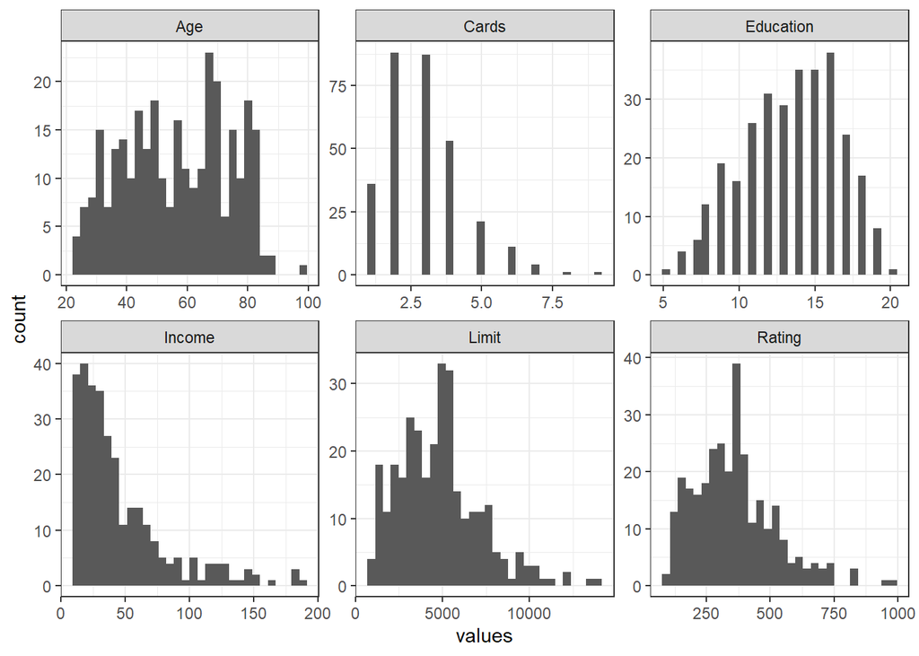

```r
library(dplyr); library(tidyr)
train %>%
  select(-Balance)%>%
  select_if(is.numeric)%>%
  pivot_longer(cols = 1:6,names_to = 'numeric_predictor', values_to = 'values'  )%>%
  ggplot(aes(x = values))+
  geom_histogram()+
  facet_wrap(numeric_predictor~., scales = 'free')+
  theme_bw()
```

Examine frequency distribution for categorical predictors

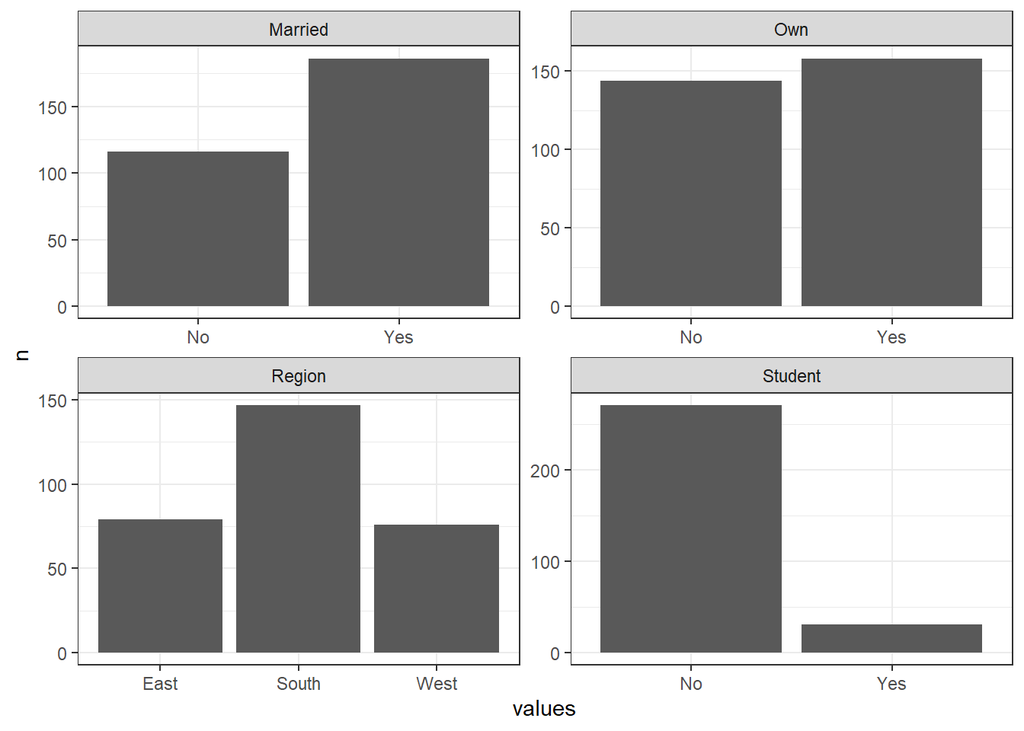

```r
library(dplyr); library(tidyr)
train %>%
  select_if(is.factor)%>%
  pivot_longer(cols = 1:4,names_to = 'categorical_predictor', values_to = 'values'  )%>%
  group_by(categorical_predictor, values)%>%
  count()%>%
  ungroup()%>%
  ggplot(aes(x = values, y = n))+
  geom_col()+
  facet_wrap(categorical_predictor~., scales = 'free')+
  theme_bw()
```

# Tree 1

We will use the library `rpart` to estimate trees, but note there are a number of other libraries that can be used. Since we are estimating a regression tree, we will set the method to `anova`.

## Estimate

We will begin by predicting Credit Card `Balance` with just one predictor, `Age`.

```r
library(rpart); library(rpart.plot)
tree1 = rpart(Balance~Age,data = train, method = 'anova')
```

## Inference

Here are model results.

```r
summary(tree1)
```

```
## Call:
## rpart(formula = Balance ~ Age, data = train, method = "anova")
##   n= 302
##
##           CP nsplit rel error   xerror       xstd
## 1 0.04128429      0 1.0000000 1.008176 0.07206441
## 2 0.01643858      2 0.9174314 1.007696 0.07527244
## 3 0.01154186      3 0.9009928 1.003318 0.07470709
## 4 0.01000000      4 0.8894510 1.034178 0.07606313
##
## Variable importance
## Age
## 100
##
## Node number 1: 302 observations,    complexity param=0.04128429
##   mean=524.9205, MSE=216150.7
##   left son=2 (154 obs) right son=3 (148 obs)
##   Primary splits:
##       Age < 56.5 to the right, improve=0.03073817, (0 missing)
##
## Node number 2: 154 observations,    complexity param=0.01643858
##   mean=445.013, MSE=195368.2
##   left son=4 (102 obs) right son=5 (52 obs)
##   Primary splits:
##       Age < 75.5 to the left,  improve=0.0356659, (0 missing)
##
## Node number 3: 148 observations,    complexity param=0.04128429
##   mean=608.0676, MSE=224218.1
##   left son=6 (58 obs) right son=7 (90 obs)
##   Primary splits:
##       Age < 38.5 to the left,  improve=0.1019567, (0 missing)
##
## Node number 4: 102 observations,    complexity param=0.01154186
##   mean=385.4118, MSE=167833.5
##   left son=8 (30 obs) right son=9 (72 obs)
##   Primary splits:
##       Age < 69.5 to the right, improve=0.04401093, (0 missing)
##
## Node number 5: 52 observations
##   mean=561.9231, MSE=228742.8
##
## Node number 6: 58 observations
##   mean=419.7241, MSE=150902.9
##
## Node number 7: 90 observations
##   mean=729.4444, MSE=233872.8
##
## Node number 8: 30 observations
##   mean=252.2667, MSE=90956.26
##
## Node number 9: 72 observations
##   mean=440.8889, MSE=189401.4
```

Model summary is easier to interpret as a Decision Tree.

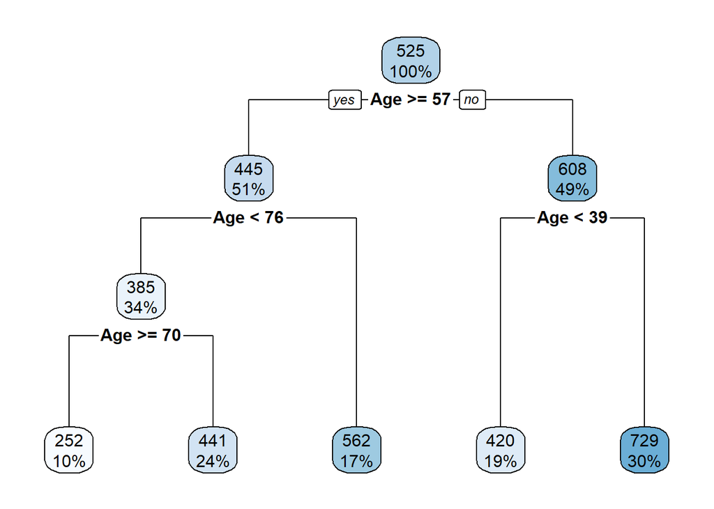

```r
rpart.plot(tree1)
```

Based on the above result, does it seem like Age is predictive of Average Credit Card Balance? What is the predicted Credit Card Balance of a 21 year old unmarried college student? What percentage of the (train) data falls in this category?

## Predict

The simplicity of the Tree makes it easy to derive predictions. However, this manual approach may not scale well when wants a number of predictions. Also, for large complex trees, navigating the tree can be tedious. Like for linear regression, one can use the `predict` function to get point predictions or a vector of predictions. For a regression tree, the default type is “vector”.

```r
predict(tree1, newdata = data.frame(Age = 21), type='vector')
```

```
##        1
## 419.7241
```

Next, let us examine predictions for the first ten observations.

```r
predict(tree1)[1:10]
```

```
##        2        3        4        5        7        8        9       10
## 561.9231 252.2667 419.7241 440.8889 419.7241 561.9231 440.8889 729.4444
##       12       13
## 440.8889 440.8889
```

The predictions in regression trees are the mean of the outcome variable for a given region. Each region is represented by a leaf in the Tree. Therefore, the number of unique predictions is the same as the number of leaves. One can view this in the Tree above or verify it by examining the prediction vector.

```r
unique(predict(tree1))
```

```
## [1] 561.9231 252.2667 419.7241 440.8889 729.4444
```

# Tree 2

Next, we will use all predictors to estimate Average Credit Card Balance.  
## Estimate

```r
library(rpart); library(rpart.plot)
tree2 = rpart(Balance~.,data = train, method = 'anova')
```

## Inference

The Tree `summary` is tedious to interpret.

```r
summary(tree2)
```

```
## Call:
## rpart(formula = Balance ~ ., data = train, method = "anova")
##   n= 302
##
##           CP nsplit rel error    xerror       xstd
## 1 0.58500515      0 1.0000000 1.0047148 0.07189478
## 2 0.13558871      1 0.4149948 0.4696279 0.03979379
## 3 0.05723065      2 0.2794061 0.3360741 0.03605076
## 4 0.03459346      3 0.2221755 0.2837131 0.03072979
## 5 0.02545314      4 0.1875820 0.2408035 0.02504813
## 6 0.01446963      5 0.1621289 0.2088050 0.02107400
## 7 0.01242193      6 0.1476593 0.2023522 0.02136595
## 8 0.01098103      7 0.1352373 0.1832016 0.02003590
## 9 0.01000000      9 0.1132753 0.1845470 0.02043795
##
## Variable importance
##     Limit    Rating    Income       Age   Student     Cards Education
##        38        37        18         2         2         1         1
##
## Node number 1: 302 observations,    complexity param=0.5850052
##   mean=524.9205, MSE=216150.7
##   left son=2 (201 obs) right son=3 (101 obs)
##   Primary splits:
##       Limit   < 5331     to the left,  improve=0.58500520, (0 missing)
##       Rating  < 352.5    to the left,  improve=0.56622380, (0 missing)
##       Income  < 62.3705  to the left,  improve=0.19872060, (0 missing)
##       Student splits as  LR,           improve=0.06930734, (0 missing)
##       Age     < 56.5     to the right, improve=0.03073817, (0 missing)
##   Surrogate splits:
##       Rating    < 404      to the left,  agree=0.977, adj=0.931, (0 split)
##       Income    < 58.566   to the left,  agree=0.818, adj=0.455, (0 split)
##       Age       < 81.5     to the left,  agree=0.685, adj=0.059, (0 split)
##       Education < 6.5      to the right, agree=0.675, adj=0.030, (0 split)
##
## Node number 2: 201 observations,    complexity param=0.1355887
##   mean=272.8507, MSE=80292.72
##   left son=4 (104 obs) right son=5 (97 obs)
##   Primary splits:
##       Limit   < 3570.5   to the left,  improve=0.54842190, (0 missing)
##       Rating  < 275.5    to the left,  improve=0.54613680, (0 missing)
```

[output cut: 117 more lines]

```
##   Surrogate splits:
##       Rating < 559      to the left,  agree=0.984, adj=0.875, (0 split)
##       Income < 96.354   to the left,  agree=0.905, adj=0.250, (0 split)
##
## Node number 44: 36 observations
##   mean=440.2778, MSE=20665.42
##
## Node number 45: 28 observations
##   mean=667.1786, MSE=11666.22
##
## Node number 50: 55 observations
##   mean=898.7636, MSE=27355.93
##
## Node number 51: 8 observations
##   mean=1234.25, MSE=23628.44
```

On the other hand, the visual of the tree is easy to understand and explain to others.

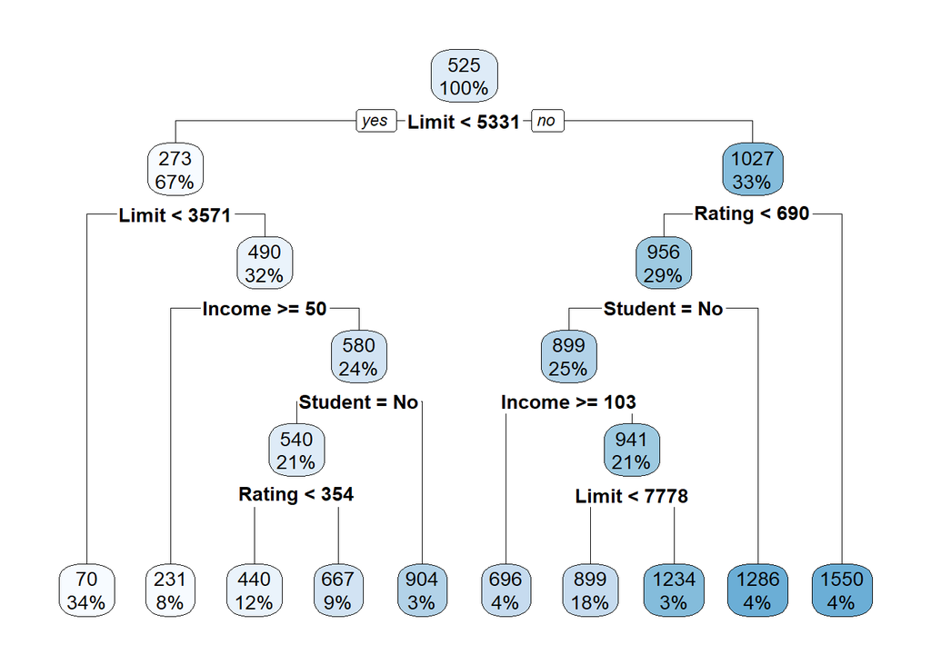

```r
rpart.plot(tree2)
```

Trees automatically conduct feature selection. Of all the predictors in the dataset, only the predictors included in the Tree visualization above have an influence on Balance.

The relative importance of the predictors can be determined by examining reduction in SSE attributed to each split. Intuitively, predictors that appear higher in the tree, or that appear multiple times in the tree will be more important than predictors that appear lower in the tree or not at all. Visual inspection of the above Tree indicates “Limit” is the most important, second is “Rating” and so on. Alternatively, one can extract relative importance from the Tree object. However, be aware that the Tree object, `tree2` also lists variable importance for predictors not included in the final tree!

```r
tree2$variable.importance
```

```
##      Limit     Rating     Income        Age    Student      Cards  Education
## 52266204.3 49818992.1 24617877.9  3206320.2  2606058.3  1501781.8  1282533.8
##    Married
##   547477.9
```

## Predict

Next, let us use “tree2” to construct predictions for the train sample. Since type = ‘vector’ is the default, it has not been included in `predict`.

```r
pred2 = predict(tree2)
```

Let us evaluate the quality of predictions on the train sample by comparing them to the true values.

```r
data.frame(Predicted_Balance = pred2,
           Balance = train$Balance)[1:5,]
```

|  | Predicted_Balance | Balance |
| --- | --- | --- |
| 2 | 1286.30769 | 903 |
| 3 | 696.23077 | 580 |
| 4 | 696.23077 | 964 |
| 5 | 231.20000 | 331 |
| 7 | 70.19231 | 203 |

Root Mean Squared Error (rmse) can summarize the quality of predictions.

```r
rmse2 = sqrt(mean((pred2 - train$Balance)^2)); rmse2
```

```
## [1] 156.4753
```

An alternative to typing out the formula is `library(Metrics)` which implements a number of model performance functions.

```r
library(Metrics)
rmse(actual = train$Balance,
     predicted = pred2)
```

```
## [1] 156.4753
```

# Tree Control

`rpart` contains a number of control parameters to affect the growth and complexity of the tree.

1. minsplit: the minimum number of observations that must exist in a node in order for a split to be attempted.
2. minbucket: the minimum number of observations in any terminal node
3. maxdepth: the maximum depth of any node of the final tree
4. cp: complexity parameter

For more information on controls, run `?rpart.control` or see [documentation for rpart.control](https://www.rdocumentation.org/packages/rpart/versions/4.1-15/topics/rpart.control). These control parameters are also referred to as model hyperparameters.

Among these, minsplit, minbucket, and maxdepth directly impact the size of the tree. The complexity parameter, cp is used to add a penalty for a large tree. Here size of the tree is measured by number of leaves. The penalty is the product of cp and number of leaves. So, large values of cp will result in smaller trees while small values of cp will result in larger more complex trees.

We will examine the effect of changing each one of these parameters on Tree size. Our baseline for comparison is the default values used in `tree2` above.

## minsplit

Default value for minsplit is 20. Increasing minsplit leads to a smaller tree.

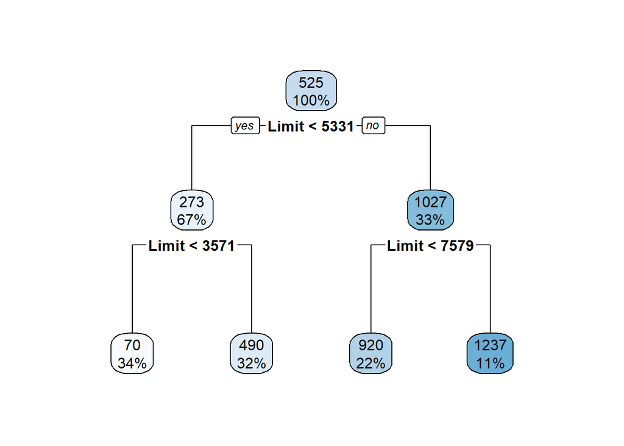

```r
tree3 = rpart(Balance~.,data = train, method = 'anova', control = rpart.control(minsplit = 100))
rpart.plot(tree3)
```

## minbucket

Default value for minbucket is 6 (=20/3). Increasing minbucket leads to a smaller tree.

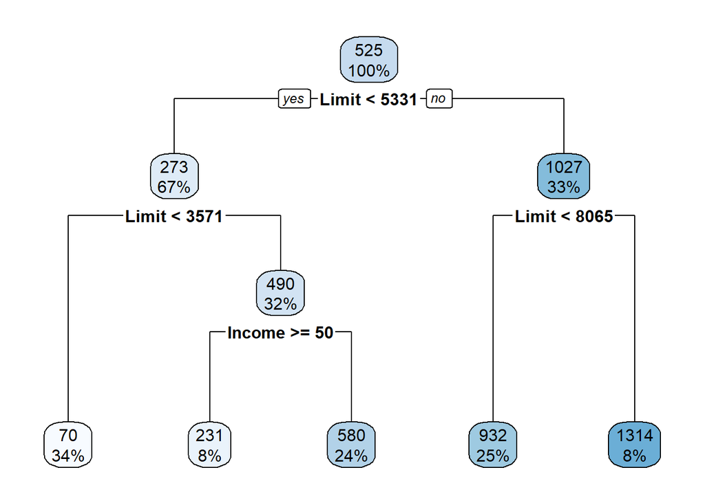

```r
tree4 = rpart(Balance~.,data = train, method = 'anova', control = rpart.control(minbucket = 25))
rpart.plot(tree4)
```

## maxdepth

Smaller the value of maxdepth, smaller the tree. A depth of 2 implies, two levels of nodes after the root node.

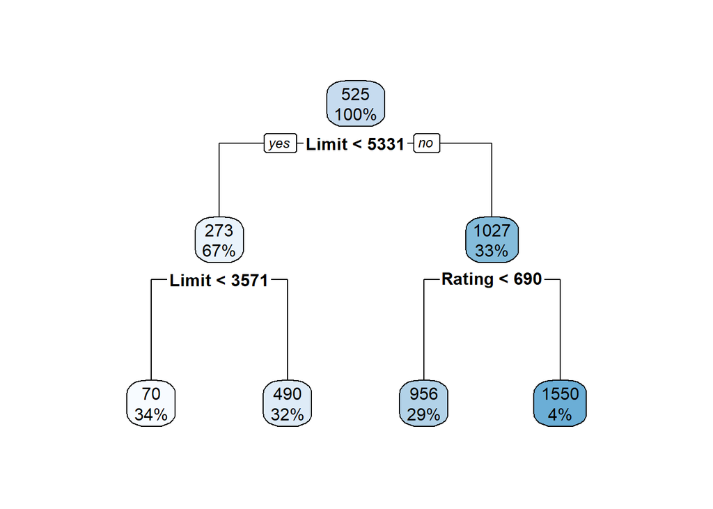

```r
tree5 = rpart(Balance~.,data = train, method = 'anova', control = rpart.control(maxdepth = 2))
rpart.plot(tree5)
```

## cp

Larger the complexity parameter, cp, the greater the penalty for complexity which will result in smaller trees. The default value of cp is 0.01.

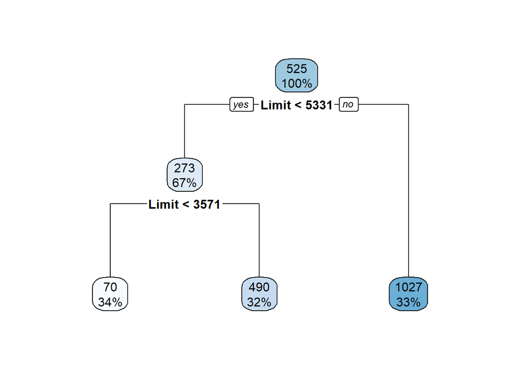

```r
tree6 = rpart(Balance~.,data = train, method = 'anova', control = rpart.control(cp = 0.1))
rpart.plot(tree6)
```

Let us examine RMSE for a cp of 0.1 and compare that to tree2 which used the default cp of 0.01

```r
pred6 = predict(tree6)
rmse6 = sqrt(mean((pred6 - train$Balance)^2)); rmse6
```

```
## [1] 245.7515
```

Let us experiment with a lower cp of 0.001 to see its impact on RMSE. As expected, this results in a large bushy Tree.

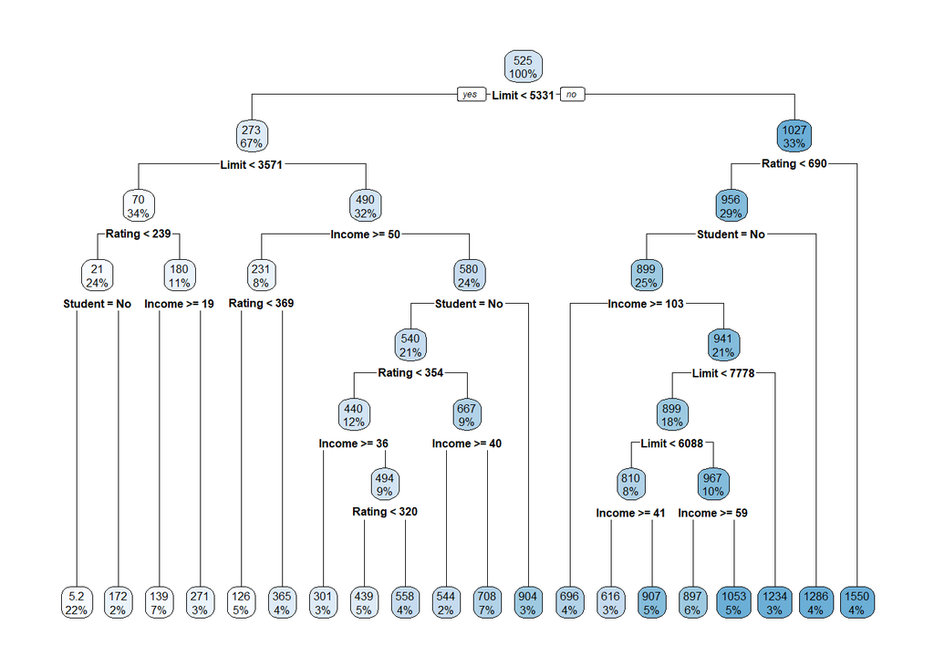

```r
tree7 = rpart(Balance~., data = train, method = 'anova', control = rpart.control(cp = 0.001))
rpart.plot(tree7)
```

```r
pred7 = predict(tree7)
rmse7 = sqrt(mean((pred7 - train$Balance)^2)); rmse7
```

```
## [1] 124.9686
```

To sum up, the results indicate that lower the value of cp, the better the quality of predictions in the train sample.

```r
data.frame(Tree = c('tree2', 'tree6', 'tree7'),
           cp = c(0.01, 0.1,  0.001),
           rmse_train = c(rmse2, rmse6, rmse7))%>%
  arrange(desc(cp))
```

| Tree | cp | rmse_train |
| --- | --- | --- |
| tree6 | 0.100 | 245.7515 |
| tree2 | 0.010 | 156.4753 |
| tree7 | 0.001 | 124.9686 |

The ultimate test of a model is how it performs on a different sample. So, we will now evaluate the predictions of the three Tree models on the test sample beginning with tree2.

```r
pred2_test = predict(tree2, newdata = test, type = 'vector')
rmse2_test = sqrt(mean((pred2_test - test$Balance)^2))
```

We will repeat this for tree6 and tree7.

```r
pred6_test = predict(tree6, newdata = test, type = 'vector')
rmse6_test = sqrt(mean((pred6_test - test$Balance)^2))
pred7_test = predict(tree7, newdata = test, type = 'vector')
rmse7_test = sqrt(mean((pred7_test - test$Balance)^2))
```

## Results

```r
data.frame(Tree = c('tree2', 'tree6', 'tree7'),
           cp = c(0.01, 0.1,  0.001),
           rmse_train = c(rmse2, rmse6, rmse7),
           rmse_test = c(rmse2_test, rmse6_test, rmse7_test))%>%
  arrange(desc(cp))
```

| Tree | cp | rmse_train | rmse_test |
| --- | --- | --- | --- |
| tree6 | 0.100 | 245.7515 | 251.2849 |
| tree2 | 0.010 | 156.4753 | 170.4549 |
| tree7 | 0.001 | 124.9686 | 143.2453 |

In this particular instance, tree7 with a cp of 0.001 has the best RMSE on both train and test. However, note that generally as cp becomes smaller, the model performs better on the train sample but on the test sample performance improves initially then gets worse.